# ELSA-sex

Harmonization: Stefanos Tyrovolas and Blanca Mellor ; R scripts: Laia Egea ; Revised by Albert Sanchez-Niubo

2017-09-01

# 1 Installation, loading packages and access to Opal

# 2 Description of the DataSchema variable: `Biological Sex`

- Short name: `sex`
- Variable label: `biological sex`
- Variable description**: `participant's biological sex`
- Domain: `Socio-demographic and economic characteristics`
- Value type: `categorical`
- Category coding:

| **Code** | **Category Label** |
| --- | --- |
| 0 | female |
| 1 | male |

- Category missings:

| **Code** | **Category Label** |
| --- | --- |
| 991 | CAPI/interviewer error |
| 992 | Impute |
| 993 | Disable to measure |
| 994 | Not applicable |
| 995 | Does not answer |
| 996 | Not attempt/not done |
| 997 | Refuse |
| 998 | Do not know |
| 999 | Missing |

# 3 ELSA study

## 3.1 ELSA - Wave 1

### 3.1.1 1. Description and statistics of the study-specific variables

- Name: `indsex`
- Label: `Sex - Priority: DiSex, DhSex`
- Table name in Opal: `wave_1_core_data_v3`
- Categories:

| **Code** | **Category Label** |
| --- | --- |
| 1 | Male |
| 2 | Female |
| -1 | Not applicable |
| -8 | Not known |
| -9 | Refusal |

**R script:**

```r
opal.assign.table.tibble(o, 'ELSA_w1_sex','ELSA.wave_1_core_data_v3', variables=list('indsex'), missings = TRUE)
```

```r
ELSA_w1_sex <- opal.execute(o,'ELSA_w1_sex')
Categorical_summary(var = ELSA_w1_sex$indsex, missing_values = NA)
```

```
## $n
## [1] 12099
##
## $n_na
## [1] 0
##
## $values_table
##                  1       2
## Frequency  5335.00 6764.00
## Percentage   44.09   55.91
```

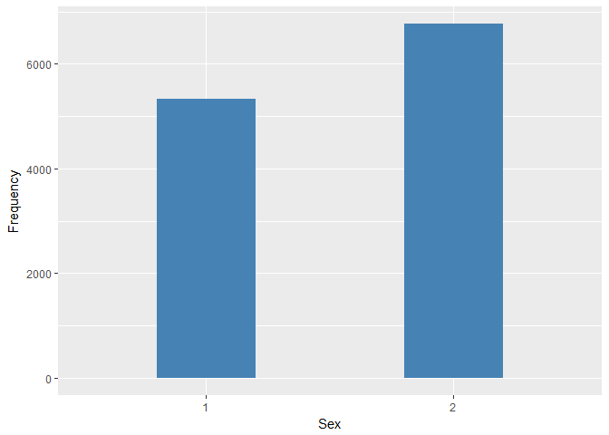

```r
ggplot(ELSA_w1_sex, aes(x=factor(indsex))) + geom_bar(stat="count", width=0.4, fill="steelblue") + xlab("Sex") + ylab("Frequency")
```

### 3.1.2 2. Harmonization script

Study-specific variable `indsex` should be recoded as follows:

- `1 "Male" into 1`
- `2 "Female" into 0`

There are not missing values, so other category codes like `-1`, `-8` or `-9` were not taking into account in the harmonisation.

**R script:**

```r
ELSA_ds_w1 <- tibble(id=ELSA_w1_sex$id)
ELSA_ds_w1$sex <- recode(ELSA_w1_sex$indsex, "1=1; 2=0")
ELSA_ds_w1$sex <- labelled(ELSA_ds_w1$sex, labels = c("Female"=0, "Male"=1, "Missing"=999, "Do not know"=998, "Refuse"=997, "Not attempt not done"=996, "Does not answer"=995,  "Not applicable"=994, "Disable to measure"=993, "Impute"=992, "CAPI interviewer error"=991))
```

### 3.1.3 3. Statistics of the new harmonized variable

**R script:**

```r
Categorical_summary(var = ELSA_ds_w1$sex, missing_values = c(991, 992, 993, 994, 995, 996, 997, 998, 999))
```

```
## $n
## [1] 12099
##
## $values_table
##                  0       1
## Frequency  6764.00 5335.00
## Percentage   55.91   44.09
##
## $missing_values_table
##            991 992 993 994 995 996 997 998 999 NA
## Frequency    0   0   0   0   0   0   0   0   0  0
## Percentage   0   0   0   0   0   0   0   0   0  0
```

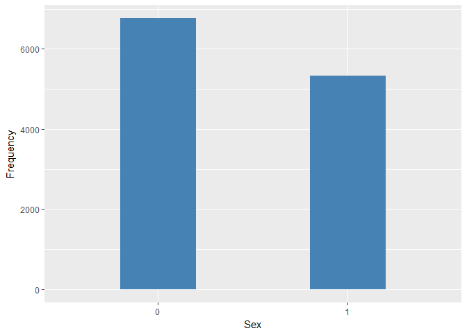

```r
ggplot(ELSA_ds_w1, aes(x=factor(sex))) + geom_bar(stat="count", width=0.4, fill="steelblue") + xlab("Sex") + ylab("Frequency")
```

### 3.1.4 4. Validation

**R script:**

```r
AfterH <- table(ELSA_ds_w1$sex)
BeforeH <- table(ELSA_w1_sex$indsex)[c(2,1)]
C <- rbind(BeforeH,AfterH)
colnames(C) <- c("2->0","1")
C
```

```
##         2->0    1
## BeforeH 6764 5335
## AfterH  6764 5335
```

### 3.1.5 5. Quality estimation

[Comments on the quality of the new harmonised variable.]

### 3.1.6 6. Import to OPAL

**R script:** (uncomment when necessary)

```r
#val_labels(ELSA_ds_w1) <- NULL
#opal.assign.data(o, 'ELSA_ds_w1', ELSA_ds_w1)
#opal.symbol_import(o,'ELSA_ds_w1', project='_Athlos_Harm_Dataset')
```

## 3.2 ELSA - Wave 2

### 3.2.1 1. Description and statistics of the study-specific variables

- Name: `indsex`
- Label: `Definitive sex variable. Priority: Disex, Dhsex`
- Table name in Opal: `wave_2_core_data_v4`
- Categories:

| **Code** | **Category Label** |
| --- | --- |
| 1 | Male |
| 2 | Female |
| -1 | Not applicable |
| -8 | Not known |
| -9 | Refusal |

**R script:**

```r
opal.assign.table.tibble(o, 'ELSA_w2_sex','ELSA.wave_2_core_data_v4', variables=list('indsex'), missings = TRUE)
```

```r
ELSA_w2_sex <- opal.execute(o,'ELSA_w2_sex')
Categorical_summary(var = ELSA_w2_sex$indsex, missing_values = NA)
```

```
## $n
## [1] 9432
##
## $n_na
## [1] 0
##
## $values_table
##                  1       2
## Frequency  4125.00 5307.00
## Percentage   43.73   56.27
```

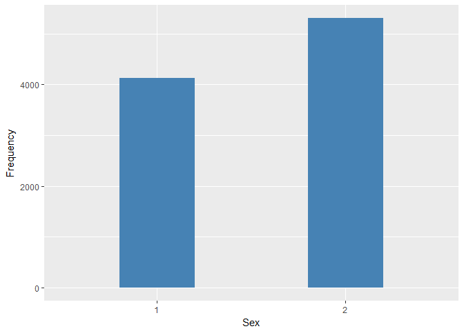

```r
ggplot(ELSA_w2_sex, aes(x=factor(indsex))) + geom_bar(stat="count", width=0.4, fill="steelblue") + xlab("Sex") + ylab("Frequency")
```

### 3.2.2 2. Harmonisation script

**R script:**

```r
ELSA_ds_w2 <- tibble(id=ELSA_w2_sex$id)
ELSA_ds_w2$sex <- recode(ELSA_w2_sex$indsex, "1=1; 2=0;-9=997; -8=998")
ELSA_ds_w2$sex <- labelled(ELSA_ds_w2$sex, labels = c("Female"=0, "Male"=1, "Missing"=999, "Do not know"=998, "Refuse"=997, "Not attempt not done"=996, "Does not answer"=995,  "Not applicable"=994, "Disable to measure"=993, "Impute"=992, "CAPI interviewer error"=991))
```

### 3.2.3 3. Statistics of the new harmonised variable

**R script:**

```r
Categorical_summary(var = ELSA_ds_w2$sex, missing_values = c(991, 992, 993, 994, 995, 996, 997, 998, 999))
```

```
## $n
## [1] 9432
##
## $values_table
##                  0       1
## Frequency  5307.00 4125.00
## Percentage   56.27   43.73
##
## $missing_values_table
##            991 992 993 994 995 996 997 998 999 NA
## Frequency    0   0   0   0   0   0   0   0   0  0
## Percentage   0   0   0   0   0   0   0   0   0  0
```

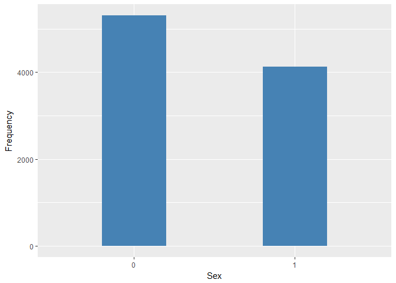

```r
ggplot(ELSA_ds_w2, aes(x=factor(sex))) + geom_bar(stat="count", width=0.4, fill="steelblue") + xlab("Sex") + ylab("Frequency")
```

### 3.2.4 4. Validation

**R script:**

```r
AfterH <- table(ELSA_ds_w2$sex)
BeforeH <- table(ELSA_w2_sex$indsex)[c(2,1)]
C <- rbind(BeforeH,AfterH)
colnames(C) <- c("2->0","1")
C
```

```
##         2->0    1
## BeforeH 5307 4125
## AfterH  5307 4125
```

### 3.2.5 5. Quality estimation

[Comments on the quality of the new harmonised variable.]

### 3.2.6 6. Import to OPAL

**R script:** (uncomment when necessary)

```r
#val_labels(ELSA_ds_w2) <- NULL
#opal.assign.data(o, 'ELSA_ds_w2', ELSA_ds_w2)
#opal.symbol_import(o,'ELSA_ds_w2', project='_Athlos_Harm_Dataset')
```

## 3.3 ELSA - Wave 3

### 3.3.1 1. Description and statistics of the study-specific variables

- Name: `indsex`
- Label: `Definitive sex variable. Priority: Disex, Dhsex`
- Table name in Opal: `wave_3_elsa_data_v4`
- Categories:

| **Code** | **Category Label** |
| --- | --- |
| 1 | Male |
| 2 | Female |
| -1 | Not applicable |
| -8 | Not known |
| -9 | Refusal |

**R script:**

```r
opal.assign.table.tibble(o, 'ELSA_w3_sex','ELSA.wave_3_elsa_data_v4', variables=list('indsex'), missings = TRUE)
```

```r
ELSA_w3_sex <- opal.execute(o,'ELSA_w3_sex')
Categorical_summary(var = ELSA_w3_sex$indsex, missing_values = NA)
```

```
## $n
## [1] 9771
##
## $n_na
## [1] 0
##
## $values_table
##                  1       2
## Frequency  4295.00 5476.00
## Percentage   43.96   56.04
```

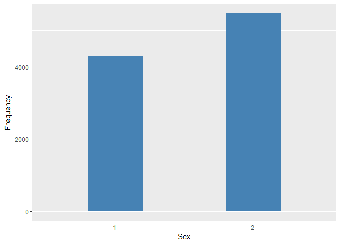

```r
ggplot(ELSA_w3_sex, aes(x=factor(indsex))) + geom_bar(stat="count", width=0.4, fill="steelblue") + xlab("Sex") + ylab("Frequency")
```

### 3.3.2 2. Harmonisation script

**R script:**

```r
ELSA_ds_w3 <- tibble(id=ELSA_w3_sex$id)
ELSA_ds_w3$sex <- recode(ELSA_w3_sex$indsex, "1=1; 2=0;-9=997; -8=998")
ELSA_ds_w3$sex <- labelled(ELSA_ds_w3$sex, labels = c("Female"=0, "Male"=1, "Missing"=999, "Do not know"=998, "Refuse"=997, "Not attempt not done"=996, "Does not answer"=995,  "Not applicable"=994, "Disable to measure"=993, "Impute"=992, "CAPI interviewer error"=991))
```

### 3.3.3 3. Statistics of the new harmonised variable

**R script:**

```r
Categorical_summary(var = ELSA_ds_w3$sex, missing_values = c(991, 992, 993, 994, 995, 996, 997, 998, 999))
```

```
## $n
## [1] 9771
##
## $values_table
##                  0       1
## Frequency  5476.00 4295.00
## Percentage   56.04   43.96
##
## $missing_values_table
##            991 992 993 994 995 996 997 998 999 NA
## Frequency    0   0   0   0   0   0   0   0   0  0
## Percentage   0   0   0   0   0   0   0   0   0  0
```

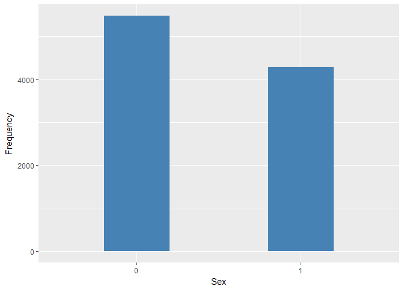

```r
ggplot(ELSA_ds_w3, aes(x=factor(sex))) + geom_bar(stat="count", width=0.4, fill="steelblue")+ xlab("Sex") + ylab("Frequency")
```

### 3.3.4 4. Validation

**R script:**

```r
AfterH <- table(ELSA_ds_w3$sex)
BeforeH <- table(ELSA_w3_sex$indsex)[c(2,1)]
C <- rbind(BeforeH,AfterH)
colnames(C) <- c("2->0","1")
C
```

```
##         2->0    1
## BeforeH 5476 4295
## AfterH  5476 4295
```

### 3.3.5 5. Quality estimation

[Comments on the quality of the new harmonised variable.]

### 3.3.6 6. Import to OPAL

**R script:** (uncomment when necessary)

```r
#val_labels(ELSA_ds_w3) <- NULL
#opal.assign.data(o, 'ELSA_ds_w3', ELSA_ds_w3)
#opal.symbol_import(o,'ELSA_ds_w3', project='_Athlos_Harm_Dataset')
```

## 3.4 ELSA - Wave 4

### 3.4.1 1. Description and statistics of the study-specific variables

- Name: `indsex`
- Label: `Definitive sex variable. Priority: Disex, Dhsex`
- Table name in Opal: `wave_4_elsa_data_v3`
- Categories:

| **Code** | **Category Label** |
| --- | --- |
| 1 | Male |
| 2 | Female |

**R script:**

```r
opal.assign.table.tibble(o, 'ELSA_w4_sex','ELSA.wave_4_elsa_data_v3', variables=list('indsex'), missings = TRUE)
```

```r
ELSA_w4_sex <- opal.execute(o,'ELSA_w4_sex')
Categorical_summary(var = ELSA_w4_sex$indsex, missing_values = NA)
```

```
## $n
## [1] 11050
##
## $n_na
## [1] 0
##
## $values_table
##                  1       2
## Frequency  4925.00 6125.00
## Percentage   44.57   55.43
```

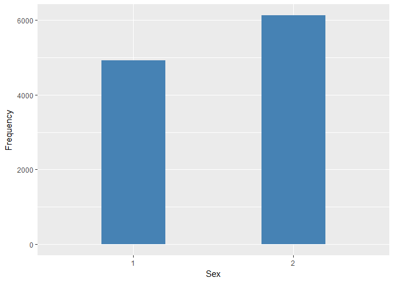

```r
ggplot(ELSA_w4_sex, aes(x=factor(indsex))) + geom_bar(stat="count", width=0.4, fill="steelblue") + xlab("Sex") + ylab("Frequency")
```

### 3.4.2 2. Harmonisation script

Study-specific variable `indsex` should be recoded as follows:

- `1 "Male" into 1`
- `2 "Female" into 0`
- `NA into 999`

**R script:**

```r
ELSA_ds_w4 <- tibble(id=ELSA_w4_sex$id)
ELSA_ds_w4$sex <- recode(ELSA_w4_sex$indsex, "1=1; 2=0;-9=997; -8=998")
ELSA_ds_w4$sex <- labelled(ELSA_ds_w4$sex, labels = c("Female"=0, "Male"=1, "Missing"=999, "Do not know"=998, "Refuse"=997, "Not attempt not done"=996, "Does not answer"=995,  "Not applicable"=994, "Disable to measure"=993, "Impute"=992, "CAPI interviewer error"=991))
```

### 3.4.3 3. Statistics of the new harmonised variable

**R script:**

```r
Categorical_summary(var = ELSA_ds_w4$sex, missing_values = c(991, 992, 993, 994, 995, 996, 997, 998, 999))
```

```
## $n
## [1] 11050
##
## $values_table
##                  0       1
## Frequency  6125.00 4925.00
## Percentage   55.43   44.57
##
## $missing_values_table
##            991 992 993 994 995 996 997 998 999 NA
## Frequency    0   0   0   0   0   0   0   0   0  0
## Percentage   0   0   0   0   0   0   0   0   0  0
```

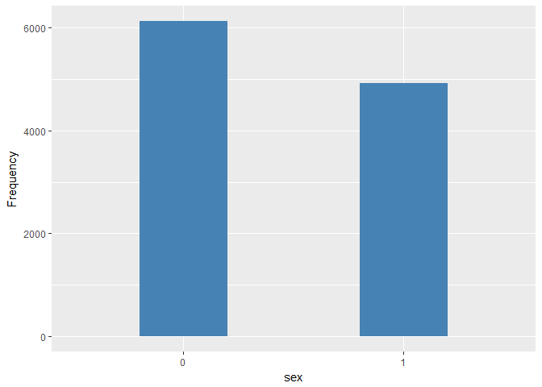

```r
ggplot(ELSA_ds_w4, aes(x=factor(sex))) + geom_bar(stat="count", width=0.4, fill="steelblue") + xlab("sex") + ylab("Frequency")
```

### 3.4.4 4. Validation

**R script:**

```r
AfterH <- table(ELSA_ds_w4$sex)
BeforeH <- table(ELSA_w4_sex$indsex)[c(2,1)]
C <- rbind(BeforeH,AfterH)
colnames(C) <- c("2->0","1")
C
```

```
##         2->0    1
## BeforeH 6125 4925
## AfterH  6125 4925
```

### 3.4.5 5. Quality estimation

[Comments on the quality of the new harmonised variable.]

### 3.4.6 6. Import to OPAL

**R script:** (uncomment when necessary)

```r
#val_labels(ELSA_ds_w4) <- NULL
#opal.assign.data(o, 'ELSA_ds_w4', ELSA_ds_w4)
#opal.symbol_import(o,'ELSA_ds_w4', project='_Athlos_Harm_Dataset')
```

## 3.5 ELSA - Wave 5

### 3.5.1 1. Description and statistics of the study-specific variables

- Name: `indsex`
- Label: `Definitive sex variable. Priority: Disex, Dhsex`
- Table name in Opal: `wave_5_elsa_data_v4`
- Categories:

| **Code** | **Category Label** |
| --- | --- |
| 1 | Male |
| 2 | Female |

**R script:**

```r
opal.assign.table.tibble(o, 'ELSA_w5_sex','ELSA.wave_5_elsa_data_v4', variables=list('indsex'), missings = TRUE)
```

```r
ELSA_w5_sex <- opal.execute(o,'ELSA_w5_sex')
Categorical_summary(var = ELSA_w5_sex$indsex, missing_values = NA)
```

```
## $n
## [1] 10274
##
## $n_na
## [1] 0
##
## $values_table
##                  1       2
## Frequency  4569.00 5705.00
## Percentage   44.47   55.53
```

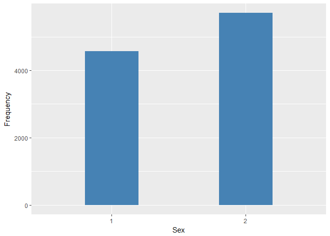

```r
ggplot(ELSA_w5_sex, aes(x=factor(indsex))) + geom_bar(stat="count", width=0.4, fill="steelblue") + xlab("Sex") + ylab("Frequency")
```

### 3.5.2 2. Harmonisation script

Study-specific variable `indsex` should be recoded as follows:

- `1 "Male" into 1`
- `2 "Female" into 0`
- `NA into 999`

**R script:**

```r
ELSA_ds_w5 <- tibble(id=ELSA_w5_sex$id)
ELSA_ds_w5$sex <- recode(ELSA_w5_sex$indsex, "1=1; 2=0;-9=997; -8=998")
ELSA_ds_w5$sex <- labelled(ELSA_ds_w5$sex, labels = c("Female"=0, "Male"=1, "Missing"=999, "Do not know"=998, "Refuse"=997, "Not attempt not done"=996, "Does not answer"=995,  "Not applicable"=994, "Disable to measure"=993, "Impute"=992, "CAPI interviewer error"=991))
```

### 3.5.3 3. Statistics of the new harmonised variable

**R script:**

```r
Categorical_summary(var = ELSA_ds_w5$sex, missing_values = c(991, 992, 993, 994, 995, 996, 997, 998, 999))
```

```
## $n
## [1] 10274
##
## $values_table
##                  0       1
## Frequency  5705.00 4569.00
## Percentage   55.53   44.47
##
## $missing_values_table
##            991 992 993 994 995 996 997 998 999 NA
## Frequency    0   0   0   0   0   0   0   0   0  0
## Percentage   0   0   0   0   0   0   0   0   0  0
```

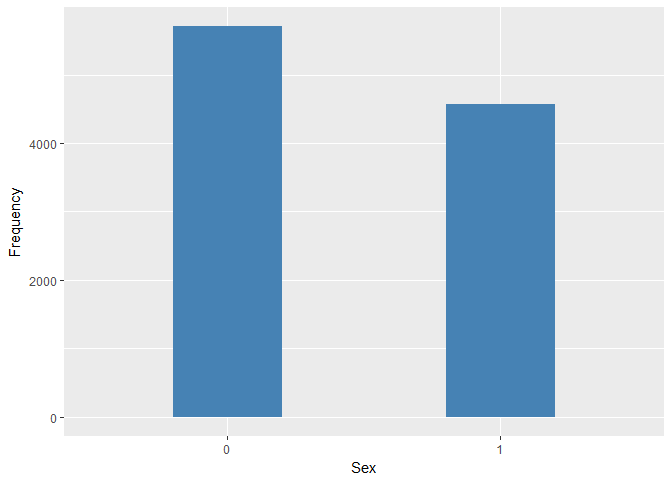

```r
ggplot(ELSA_ds_w5, aes(x=factor(sex))) + geom_bar(stat="count", width=0.4, fill="steelblue") + xlab("Sex") + ylab("Frequency")
```

### 3.5.4 4. Validation

**R script:**

```r
AfterH <- table(ELSA_ds_w5$sex)
BeforeH <- table(ELSA_w5_sex$indsex)[c(2,1)]
C <- rbind(BeforeH,AfterH)
colnames(C) <- c("2->0","1")
C
```

```
##         2->0    1
## BeforeH 5705 4569
## AfterH  5705 4569
```

### 3.5.5 5. Quality estimation

[Comments on the quality of the new harmonised variable.]

### 3.5.6 6. Import to OPAL

**R script:** (uncomment when necessary)

```r
#val_labels(ELSA_ds_w5) <- NULL
#opal.assign.data(o, 'ELSA_ds_w5', ELSA_ds_w5)
#opal.symbol_import(o,'ELSA_ds_w5', project='_Athlos_Harm_Dataset')
```